# Does Allen’s rule still apply to the world’s Birds?

Karim Bolis u6671566

14/10/23

# Word/figure count

Words: 1989 Figures: 7

# Location on GitHub

https://github.com/karim-bolis/DS4B-final-project

# Data Description

Avonet is an open-source database of morphological, geographical and ecological data for all bird species. It was compiled by Catherine Sheard and Joseph Tobias to serve as a tool for testing out theories in evolutionary biology, ecology and ecosystem science for the birds. (Tobias et al. 2021)

# Questions/Aims

## Introduction

# Raw data

Download the file named “AVONET from Supplementary dataset 1.xlsx” from https://figshare.com/articles/dataset/AVONET_morphological_ecological_and_geographical_data_for_all_birds_Tobias_et_al_2021_Ecology_Letters_/16586228.

WorldClim data is downloaded below.

```r
library(raster)
worldclim = getData("worldclim",var="bio",res=2.5, path="raw_data")
```

# Data wrangling

```r
library(tidyverse)
library(readxl)

raw_avonet = read_excel("raw_data/AVONET Supplementary dataset 1.xlsx", sheet=4)
avonet = as_tibble(raw_avonet)
avonet = avonet %>%
  mutate(row_id = row_number()) %>%
  select(row_id, everything()) %>%
  mutate(Centroid.Latitude=as.double(Centroid.Latitude)) %>%
  mutate(Centroid.Longitude=as.double(Centroid.Longitude)) %>%
  mutate(Hand.Wing.Index=`Hand-Wing.Index`)
write_csv(avonet, file = "processed_data/tidied_data.csv")

excluded_data <- read_csv("processed_data/excluded_data.csv")
tidied_data <- read_csv("processed_data/tidied_data.csv")
cleaned_data <- tidied_data %>%
  anti_join(excluded_data, by = "row_id")

write_csv(cleaned_data, file = "processed_data/cleaned_data.csv")

avonet <- read_csv("processed_data/cleaned_data.csv")
```

# Sanity checks

Most of the sanity checking was done in the data cleaning document. These checks ensure that data types are consistent with how they appear, that all species have location information to find their living range mean annual temperature and that none of the traits studied have been inferred from close relatives.

```r
summary(avonet)
```

```
##      row_id       Species3           Family3             Order3
##  Min.   :   1   Length:9094        Length:9094        Length:9094
##  1st Qu.:2484   Class :character   Class :character   Class :character
##  Median :5005   Mode  :character   Mode  :character   Mode  :character
##  Mean   :4993
##  3rd Qu.:7495
##  Max.   :9993
##
##  Total.individuals     Female             Male            Unknown
##  Min.   :  3.000   Min.   :  0.000   Min.   :  0.000   Min.   :  0.000
##  1st Qu.:  5.000   1st Qu.:  2.000   1st Qu.:  2.000   1st Qu.:  0.000
##  Median :  5.000   Median :  2.000   Median :  3.000   Median :  0.000
##  Mean   :  9.435   Mean   :  3.184   Mean   :  4.778   Mean   :  1.473
##  3rd Qu.: 10.000   3rd Qu.:  4.000   3rd Qu.:  5.000   3rd Qu.:  1.000
##  Max.   :527.000   Max.   :134.000   Max.   :225.000   Max.   :400.000
##
##  Complete.measures Beak.Length_Culmen Beak.Length_Nares   Beak.Width
##  Min.   :  3.000   Min.   :  4.70     Min.   :  1.6     Min.   : 0.900
##  1st Qu.:  4.000   1st Qu.: 14.70     1st Qu.:  8.5     1st Qu.: 3.700
##  Median :  4.000   Median : 19.90     Median : 11.8     Median : 5.000
##  Mean   :  4.848   Mean   : 26.79     Mean   : 17.4     Mean   : 6.652
##  3rd Qu.:  4.000   3rd Qu.: 28.90     3rd Qu.: 18.2     3rd Qu.: 7.800
##  Max.   :101.000   Max.   :414.20     Max.   :389.8     Max.   :88.900
##
##    Beak.Depth      Tarsus.Length     Wing.Length     Kipps.Distance
##  Min.   :  1.000   Min.   :  2.50   Min.   :  0.10   Min.   :  0.10
##  1st Qu.:  3.800   1st Qu.: 17.40   1st Qu.: 66.92   1st Qu.: 11.10
##  Median :  5.800   Median : 22.00   Median : 92.50   Median : 20.10
##  Mean   :  8.168   Mean   : 29.07   Mean   :127.00   Mean   : 38.41
##  3rd Qu.:  9.500   3rd Qu.: 31.60   3rd Qu.:147.20   3rd Qu.: 44.67
##  Max.   :110.900   Max.   :475.00   Max.   :789.90   Max.   :419.00
##
##    Secondary1     Hand-Wing.Index  Tail.Length          Mass
##  Min.   :  0.10   Min.   : 0.10   Min.   :  0.10   Min.   :     1.9
##  1st Qu.: 53.30   1st Qu.:15.40   1st Qu.: 50.30   1st Qu.:    15.0
##  Median : 70.50   Median :21.40   Median : 68.60   Median :    36.0
##  Mean   : 88.43   Mean   :25.92   Mean   : 87.92   Mean   :   275.8
##  3rd Qu.:100.90   3rd Qu.:32.60   3rd Qu.:101.88   3rd Qu.:   126.0
##  Max.   :629.10   Max.   :73.30   Max.   :812.80   Max.   :111000.0
##
```

[output cut: 25 more lines]

```
##  Min.   :-65.120   Min.   :-71.040   Min.   :-178.41    Min.   :        1
##  1st Qu.: -2.277   1st Qu.:-10.020   1st Qu.: -68.27    1st Qu.:   103392
##  Median : 10.230   Median : -0.020   Median :  20.52    Median :   617537
##  Mean   : 13.048   Mean   :  3.389   Mean   :  15.48    Mean   :  2952754
##  3rd Qu.: 25.425   3rd Qu.: 16.635   3rd Qu.: 101.26    3rd Qu.:  2804295
##  Max.   : 85.010   Max.   : 78.430   Max.   : 179.08    Max.   :136304432
##
##  Species.Status     Hand.Wing.Index
##  Length:9094        Min.   : 0.10
##  Class :character   1st Qu.:15.40
##  Mode  :character   Median :21.40
##                     Mean   :25.92
##                     3rd Qu.:32.60
##                     Max.   :73.30
##
```

```r
any(is.na(avonet$Centroid.Latitude))
```

```
## [1] FALSE
```

```r
any(is.na(avonet$Centroid.Longitude))
```

```
## [1] FALSE
```

```r
unique(avonet$Traits.inferred)
```

```
## [1] NA          "Body Mass"
```

# Report

## Obtaining annual temperature

```r
library(raster)

source("extra_functions.R")
```

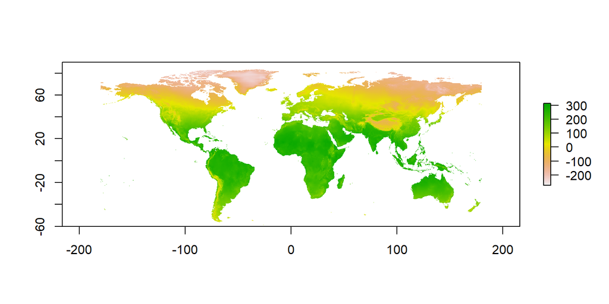

```r
worldclim <- worldclim[[1]]
plot(worldclim)
```

```r
avonet = add_mean_annual_temp(avonet)

head(avonet)
```

```
## # A tibble: 6 × 39
##   row_id Species3          Family3 Order3 Total.individuals Female  Male Unknown
##    <dbl> <chr>             <chr>   <chr>              <dbl>  <dbl> <dbl>   <dbl>
## 1      2 Accipiter badius  Accipi… Accip…                10      4     6       0
## 2      5 Accipiter brevip… Accipi… Accip…                 8      4     4       0
## 3      7 Accipiter castan… Accipi… Accip…                 6      2     2       2
## 4     10 Accipiter cirroc… Accipi… Accip…                 5      2     3       0
## 5     11 Accipiter collar… Accipi… Accip…                 7      1     5       1
## 6     12 Accipiter cooper… Accipi… Accip…                 5      2     3       0
## # ℹ 31 more variables: Complete.measures <dbl>, Beak.Length_Culmen <dbl>,
## #   Beak.Length_Nares <dbl>, Beak.Width <dbl>, Beak.Depth <dbl>,
## #   Tarsus.Length <dbl>, Wing.Length <dbl>, Kipps.Distance <dbl>,
## #   Secondary1 <dbl>, `Hand-Wing.Index` <dbl>, Tail.Length <dbl>, Mass <dbl>,
## #   Mass.Source <chr>, Mass.Refs.Other <chr>, Inference <chr>,
## #   Traits.inferred <chr>, Reference.species <chr>, Habitat <chr>,
## #   Habitat.Density <dbl>, Migration <dbl>, Trophic.Level <chr>, …
```

## PCA

The violin plot shows that most values in the distributions of wing and tail length sit within a small range, with lots of outliers. They have a clear linear relationship with narrow confidence intervals. To quantify the effect size, I found their pearson and spearman correlation coefficients. While both coefficients assume a linear relationship, pearson is heavily affected by outliers, so spearman performs better.

This strong relationship indicates that a Principal component analysis, which reduces data dimensionality, could provide a way to capture both sets of data and provide a stronger correlate with mean annual temperature. This technique was previously used to capture bill size from its 4 dimensional measurments. (Baldwin et al. 2023) The first principal component, capturing 86% of both variables, was added to avonet.

```r
library(psych)
summary(avonet$Wing.Length)
```

```
##    Min. 1st Qu.  Median    Mean 3rd Qu.    Max.
##     0.1    66.2    89.9   122.4   140.8   789.9
```

```r
summary(avonet$Tail.Length)
```

```
##    Min. 1st Qu.  Median    Mean 3rd Qu.    Max.
##    0.10   50.10   67.80   87.03   99.72  812.80
```

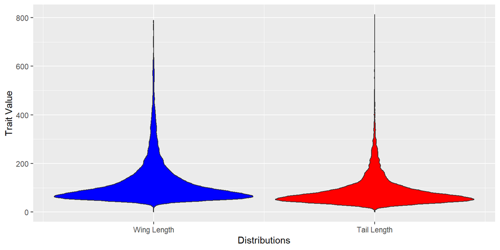

```r
ggplot(avonet, aes(x = 1, y = Wing.Length)) +
  geom_violin(fill = "blue") +
  labs(y = "Trait Value") +
  labs(x = "Distributions") +
  geom_violin(data = avonet, aes(x = 2, y = Tail.Length), fill = "red") +
  scale_x_continuous(breaks = c(1, 2), labels = c("Wing Length", "Tail Length"))
```

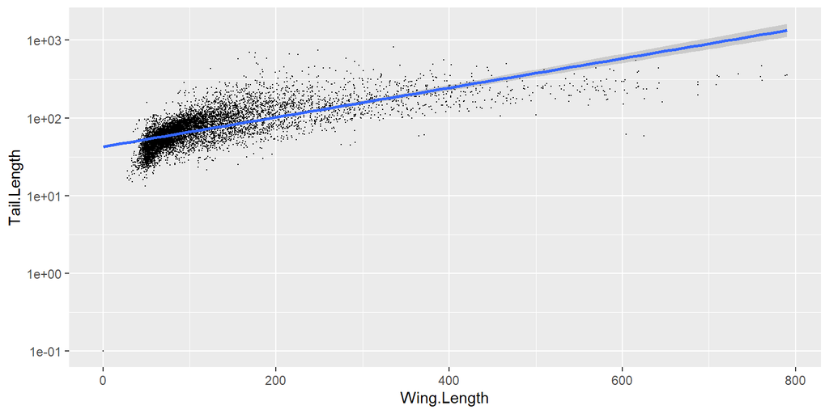

```r
ggplot(avonet, aes(x = Wing.Length, y = Tail.Length)) +
  geom_point(size = 0.01) +
  scale_y_log10() +
  geom_smooth(method = 'lm', se=TRUE, level=0.99999999)
```

```r
correlation_value_pearson = cor(avonet$Wing.Length, avonet$Tail.Length, method = "pearson")
correlation_value_spearman = cor(avonet$Wing.Length, avonet$Tail.Length, method = "spearman")
print(correlation_value_pearson)
```

```
## [1] 0.7237
```

```r
print(correlation_value_spearman)
```

```
## [1] 0.7911956
```

```r
pca_model = principal(select(avonet,Wing.Length,Tail.Length), nfactors = 2, rotate='none')
print(pca_model)
```

```
## Principal Components Analysis
## Call: principal(r = select(avonet, Wing.Length, Tail.Length), nfactors = 2,
##     rotate = "none")
## Standardized loadings (pattern matrix) based upon correlation matrix
##              PC1   PC2 h2 u2 com
## Wing.Length 0.93 -0.37  1  0 1.3
## Tail.Length 0.93  0.37  1  0 1.3
##
##                        PC1  PC2
## SS loadings           1.72 0.28
## Proportion Var        0.86 0.14
## Cumulative Var        0.86 1.00
## Proportion Explained  0.86 0.14
## Cumulative Proportion 0.86 1.00
##
## Mean item complexity =  1.3
## Test of the hypothesis that 2 components are sufficient.
##
## The root mean square of the residuals (RMSR) is  0
##  with the empirical chi square  0  with prob <  NA
##
## Fit based upon off diagonal values = 1
```

```r
pc1 = pca_model$scores[,1]

avonet$wing_tail_pc1 = pc1
```

## Correlations

I chose to study family-level correlations, as families usually contain a sufficiently large temperature range and number of species, keeping potentially confounding effects of morphology, behavior, and ecology variation low. Additionally, families have vastly different trait value distributions, as seen in the histograms. The families studied were filtered to favor a temperature range and no. of species > 10.

[figure not shown]

```r
Anatidae_Tyrannidae <- avonet %>%
  filter(Family3 %in% c("Anatidae", "Tyrannidae"))

ggplot(Anatidae_Tyrannidae, aes(x = Wing.Length)) +
  geom_histogram(fill = "blue", color = "black") +
  facet_wrap(~Family3, ncol = 2) +
  labs(x = "Wing Length", y = "Frequency") +
  ggtitle("Histograms of PC1 Values for Anatidae and Tyrannidae")
```

```r
avonet = avonet %>%
  group_by(Family3) %>%
  mutate(temp_range=max(mean_annual_temp)-min(mean_annual_temp))

avonet = filter(avonet,temp_range>10)

avonet = avonet %>%
  group_by(Family3) %>%
  mutate(no_species_in_family=n())

avonet = filter(avonet,no_species_in_family>10)
```

I first found the distribution of p values across families for each trait. I then transformed the results to produce p-value distribution boxplots, which showed that most relationships are not significant for the traits, with only the Hand-Wing Index median falling at or below the 0.05 line, and most traits containing relatively few significant families out of 96 families total.

While the significant relationship counts featured some for all traits, Wing Length, Tail Length, Hand-Wing Index (HWI) and Kipps’ Distance contained the most. The PC1 from the Wing/Tail Length PCA seems to show a correlation between the two traits, rather than improving on them. The HWI is a metric of flight efficiency and ability to disperse in birds (Tobias et al. 2021, Claramunt 2021). It is equivalent to Kipps’ length, explaining their similar numbers, and is not a measure of appendage length, more of relative ratios. (Claramunt 2021) Research has suggested that tropical species in hotter climates have less dispersal ability, increasing their sensitivity to habitat disturbance. (Sheard et al. 2020) This may explain why it is the most negatively correlated trait.

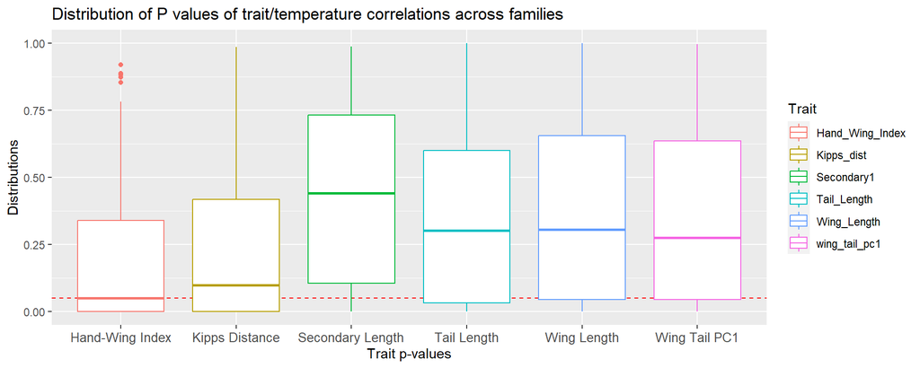

```r
correlation_values <- avonet %>%
  group_by(Family3) %>%
  summarize(
    p_value_Wing_Length = cor.test(mean_annual_temp, Wing.Length)$p.value,
    r_value_Wing_Length = cor(mean_annual_temp, Wing.Length),
    p_value_Tail_Length = cor.test(mean_annual_temp, Tail.Length)$p.value,
    r_value_Tail_Length = cor(mean_annual_temp, Tail.Length),
    p_value_wing_tail_pc1 = cor.test(mean_annual_temp, wing_tail_pc1)$p.value,
    r_value_wing_tail_pc1 = cor(mean_annual_temp, wing_tail_pc1),
    p_value_Secondary1 = cor.test(mean_annual_temp, Secondary1)$p.value,
    r_value_Secondary1 = cor(mean_annual_temp, Secondary1),
    p_value_Hand_Wing_Index = cor.test(mean_annual_temp, Hand.Wing.Index)$p.value,
    r_value_Hand_Wing_Index = cor(mean_annual_temp, Hand.Wing.Index),
    p_value_Kipps_dist = cor.test(mean_annual_temp, Kipps.Distance)$p.value,
    r_value_Kipps_dist = cor(mean_annual_temp, Kipps.Distance)
  ) %>%
  ungroup()

correlations_p_values = select(correlation_values, Family3, p_value_Wing_Length, p_value_Tail_Length, p_value_wing_tail_pc1, p_value_Secondary1, p_value_Hand_Wing_Index, p_value_Kipps_dist)

correlations_p_values = correlations_p_values %>% pivot_longer(cols=c('p_value_Wing_Length', 'p_value_Tail_Length', 'p_value_wing_tail_pc1', 'p_value_Secondary1', 'p_value_Hand_Wing_Index', 'p_value_Kipps_dist'),
                    names_to='Trait',
                    values_to='p_value')

correlations_p_values <- correlations_p_values %>%
  mutate(Trait = substr(Trait, 9, nchar(Trait)))

correlations_r_values = select(correlation_values, Family3, r_value_Wing_Length, r_value_Tail_Length, r_value_wing_tail_pc1, r_value_Secondary1, r_value_Hand_Wing_Index, r_value_Kipps_dist)

correlations_r_values = correlations_r_values %>% pivot_longer(cols=c('r_value_Wing_Length', 'r_value_Tail_Length', 'r_value_wing_tail_pc1', 'r_value_Secondary1', 'r_value_Hand_Wing_Index', 'r_value_Kipps_dist'),
                    names_to='Trait',
                    values_to='r_value')

correlations_r_values <- correlations_r_values %>%
  mutate(Trait = substr(Trait, 9, nchar(Trait)))

correlations_p_r_values <- inner_join(correlations_p_values, correlations_r_values, by = c("Family3", "Trait"))

ggplot(correlations_p_r_values, aes(x=Trait, y=p_value, color=Trait)) +
  geom_hline(yintercept = 0.05, linetype = "dashed", color = "red") +
  geom_boxplot() +
  scale_x_discrete(labels = c("Hand-Wing Index","Kipps Distance","Secondary Length","Tail Length","Wing Length","Wing Tail PC1")) +
  theme(axis.text.x = element_text(size = 10)) +
  labs(x = "Trait p-values", y = "Distributions", title = "Distribution of P values of trait/temperature correlations across families")
```

```r
length(unique(avonet$Family3))
```

```
## [1] 96
```

```r
nrow(filter(correlation_values,p_value_Wing_Length<0.05))
```

```
## [1] 25
```

```r
nrow(filter(correlation_values,p_value_Tail_Length<0.05))
```

```
## [1] 28
```

```r
nrow(filter(correlation_values,p_value_wing_tail_pc1<0.05))
```

```
## [1] 26
```

```r
nrow(filter(correlation_values,p_value_Secondary1<0.05))
```

```
## [1] 17
```

```r
nrow(filter(correlation_values,p_value_Hand_Wing_Index<0.05))
```

```
## [1] 48
```

```r
nrow(filter(correlation_values,p_value_Kipps_dist<0.05))
```

```
## [1] 40
```

The violin plots show that while most significantly correlated families for a trait show a negative correlation, all traits have at least some families where a positive trend is seen. Interestingly, correlation coefficients become scarce around 0, indicating that heavy selection pressures apply on each trait, regardless of direction. Assessing the families with the most correlation (by correlation coefficient) shows the Remizidae family has the largest negative trend for Wing Length and Kipps’ Distance, explaining 61-62% of the trait’s variation through the mean annual temperature (r=-0.78^2 –> R=0.61). Additionally, it is amongst the largest negatively correlated families for Tail Length. Amongst traits which directly measure appendage size, the Gruidae family shows the strongest positive correlation for Tail Length.

Frohlich et al. found that various body/appendage size configurations allow organisms to adapt to climates. (Frohlich et al. 2023) In their findings, tarsus size actually decreased with temperature in smaller birds, producing the opposite effect to Allen’s rule, while larger birds were more likely to obey the rule. (Frohlich et al. 2023) Indeed, Allen himself hypothesised that larger birds would be more likely to follow his rule. (Frohlich et al. 2023) The vastly different masses of Remizidae and Gruidae supports this. Additionally, Xu et al. found that passerines (Remizidae) exhibit a negative trend with annual mean temperature, while non-passerines (Gruidae) exhibit a positive trend for bill and tarsus length. (Xu 2023) It is possible, then, that Wing and Tai length are under similar selection pressures to that producing these trends in tarsus length.

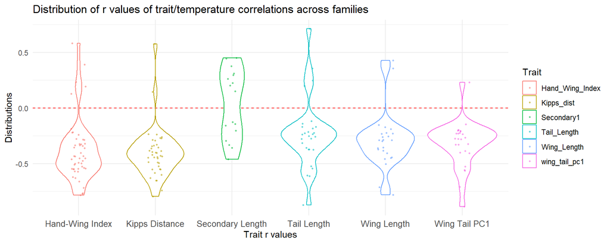

```r
correlations_significant = filter(correlations_p_r_values,p_value<0.05)

ggplot(correlations_significant, aes(x=Trait, y=r_value, color=Trait)) +
  geom_hline(yintercept = 0, linetype = "dashed", color = "red") +
  geom_violin() +
  geom_jitter(size=0.5, alpha=0.5, width = 0.1) +
  theme_minimal() +
  scale_x_discrete(labels = c("Hand-Wing Index","Kipps Distance","Secondary Length","Tail Length","Wing Length","Wing Tail PC1")) +
  theme(axis.text.x = element_text(size = 10)) +
  labs(x = "Trait r values", y = "Distributions", title = "Distribution of r values of trait/temperature correlations across families")
```

```r
extreme_family_finder <- function(correlations,trait) {
  trait_correlations = filter(correlations_significant,Trait==trait)

  most_negative = trait_correlations %>%
    arrange(r_value) %>%
    slice(1)

  most_positive = trait_correlations %>%
    arrange(desc(r_value)) %>%
    slice(1)

  print(most_negative)
  print(most_positive)
}

extreme_family_finder(correlations_significant,"Wing_Length")
```

```
## # A tibble: 1 × 4
##   Family3   Trait       p_value r_value
##   <chr>     <chr>         <dbl>   <dbl>
## 1 Remizidae Wing_Length 0.00165  -0.780
## # A tibble: 1 × 4
##   Family3   Trait       p_value r_value
##   <chr>     <chr>         <dbl>   <dbl>
## 1 Maluridae Wing_Length  0.0368   0.428
```

```r
extreme_family_finder(correlations_significant,"Kipps_dist")
```

```
## # A tibble: 1 × 4
##   Family3   Trait      p_value r_value
##   <chr>     <chr>        <dbl>   <dbl>
## 1 Remizidae Kipps_dist 0.00121  -0.793
## # A tibble: 1 × 4
##   Family3      Trait      p_value r_value
##   <chr>        <chr>        <dbl>   <dbl>
## 1 Musophagidae Kipps_dist 0.00625   0.576
```

```r
extreme_family_finder(correlations_significant,"Tail_Length")
```

```
## # A tibble: 1 × 4
##   Family3       Trait         p_value r_value
##   <chr>         <chr>           <dbl>   <dbl>
## 1 Pteroclididae Tail_Length 0.0000112  -0.871
## # A tibble: 1 × 4
##   Family3 Trait       p_value r_value
##   <chr>   <chr>         <dbl>   <dbl>
## 1 Gruidae Tail_Length 0.00411   0.714
```

```r
extreme_family_finder(correlations_significant,"Hand_Wing_Index")
```

```
## # A tibble: 1 × 4
##   Family3 Trait            p_value r_value
##   <chr>   <chr>              <dbl>   <dbl>
## 1 Gruidae Hand_Wing_Index 0.000914  -0.784
## # A tibble: 1 × 4
##   Family3      Trait           p_value r_value
##   <chr>        <chr>             <dbl>   <dbl>
## 1 Musophagidae Hand_Wing_Index 0.00551   0.583
```

```r
extreme_family_finder(correlations_significant,"Secondary1")
```

```
## # A tibble: 1 × 4
##   Family3 Trait       p_value r_value
##   <chr>   <chr>         <dbl>   <dbl>
## 1 Laridae Secondary1 0.000657  -0.461
## # A tibble: 1 × 4
##   Family3      Trait        p_value r_value
##   <chr>        <chr>          <dbl>   <dbl>
## 1 Scolopacidae Secondary1 0.0000718   0.450
```

```r
extreme_family_finder(correlations_significant,"wing_tail_pc1")
```

```
## # A tibble: 1 × 4
##   Family3       Trait            p_value r_value
##   <chr>         <chr>              <dbl>   <dbl>
## 1 Pteroclididae wing_tail_pc1 0.00000467  -0.887
## # A tibble: 1 × 4
##   Family3   Trait         p_value r_value
##   <chr>     <chr>           <dbl>   <dbl>
## 1 Sturnidae wing_tail_pc1  0.0277   0.230
```

```r
print(arrange(filter(correlations_p_r_values,Trait=="Tail_Length"),r_value))
```

```
## # A tibble: 96 × 4
##    Family3          Trait        p_value r_value
##    <chr>            <chr>          <dbl>   <dbl>
##  1 Pteroclididae    Tail_Length 1.12e- 5  -0.871
##  2 Acanthizidae     Tail_Length 3.16e- 6  -0.611
##  3 Remizidae        Tail_Length 2.80e- 2  -0.607
##  4 Fringillidae     Tail_Length 3.19e-12  -0.544
##  5 Glareolidae      Tail_Length 3.07e- 2  -0.524
##  6 Polioptilidae    Tail_Length 1.24e- 1  -0.469
##  7 Melanocharitidae Tail_Length 1.86e- 1  -0.431
##  8 Pipridae         Tail_Length 8.89e- 3  -0.374
##  9 Paradisaeidae    Tail_Length 2.32e- 2  -0.373
## 10 Laridae          Tail_Length 7.46e- 3  -0.370
## # ℹ 86 more rows
```

```r
mean(filter(avonet,Family3=="Remizidae")$Mass)
```

```
## [1] 7.284615
```

```r
mean(filter(avonet,Family3=="Gruidae")$Mass)
```

```
## [1] 5243.995
```

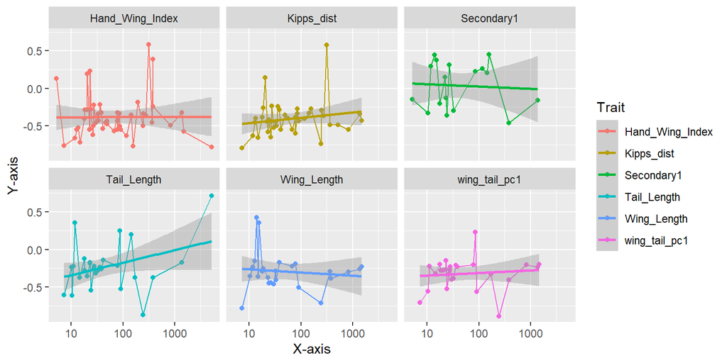

```r
mean_mass_per_family <- avonet %>%
  group_by(Family3) %>%
  summarize(mean_mass = mean(Mass, na.rm = TRUE))

correlations_significant <- correlations_significant %>%
  left_join(mean_mass_per_family, by = "Family3")

ggplot(correlations_significant, aes(x = mean_mass, y = r_value, colour = Trait)) +
  geom_point() +
  geom_line() +
  scale_x_log10() +
  geom_smooth(method = "lm", se = TRUE) +
  facet_wrap(~ Trait) +
  labs(x = "X-axis", y = "Y-axis")
```

```r
  theme_minimal()
```

[output not shown]

[output cut: 333 more lines]

[output not shown]

# References

Allen, JA 1907, ‘The Influence of Physical Conditions in the Genesis of Species’, Scientific American, vol. 63, no. 1636supp, pp. 26217–26219.

Baldwin, JW, Garcia‐Porta, J & Botero, CA 2023, ‘Complementarity in Allen’s and Bergmann’s rules among birds’, Nature Communications, vol. 14, Nature Portfolio, no. 1.

Claramunt, S 2021, ‘Flight efficiency explains differences in natal dispersal distances in birds’, Ecology, vol. 102, no. 9.

Fick, S.E. and R.J. Hijmans, 2017, ‘WorldClim 2: new 1km spatial resolution climate surfaces for global land areas’, International Journal of Climatology, vol. 37, no. 12, pp. 4302-4315.

Frӧhlich, A, Kotowska, D, Martyka, R & Symonds, MRE 2023, ‘Allometry reveals trade-offs between Bergmann’s and Allen’s rules, and different avian adaptive strategies for thermoregulation’, Nature Communications, vol. 14, no. 1.

Sheard, C, Neate-Clegg, MHC, Alioravainen, N, Jones, SEI, Vincent, C, MacGregor, HEA, Bregman, TP, Claramunt, S & Tobias, JA 2020, ‘Ecological drivers of global gradients in avian dispersal inferred from wing morphology’, Nature Communications, vol. 11, no. 1.

Symonds, Matthew R E. & Tattersall, Glenn J 2010, ‘Geographical Variation in Bill Size across Bird Species Provides Evidence for Allen’s Rule’, The American Naturalist, vol. 176, no. 2, pp. 188–197.

Tian, L & Benton, MJ 2020, ‘Predicting biotic responses to future climate warming with classic ecogeographic rules’, Current Biology, vol. 30, no. 13, pp. R744–R749.

Tobias, JA, Sheard, C, Pigot, AL, Devenish, AJM, Yang, J, Sayol, F, Neate‐Clegg, MHC, Alioravainen, N, Weeks, TL, Barber, RA, Walkden, PA, … Claramunt, S & Darski, B 2022, ‘AVONET: morphological, ecological and geographical data for all birds’, in T Coulson (ed.), Ecology Letters, vol. 25, no. 3, pp. 581–597.

Weeks, B., Harvey, C., Tobias, J.A., Sheard, C., Zhou, Z., Fouhey, D.F., 2023, ‘Skeletal morphology of bird wings is determined by thermoregulatory demand for heat dissipation in warmer climates’, In Manuscript.

Xu, Y, Price, ML, Que, P, Zhang, K, Shang, S, He, X, Wen, Z & Wang, B 2023, ‘Ecological predictors of interspecific variation in bird bill and leg lengths on a global scale’, Proceedings of The Royal Society B: Biological Sciences, vol. 290, Royal Society, no. 2003.